# SSRP: Differential Analysis

Nikita Telkar

### **Script #2 Extras**

### **0.0 Introduction**

Note: Okay, I forgot to ask you to save the `mDat` and `eNorm` objects from last time, so I’ve manually saved them within the `data` folder

**I haven’t labelled the code chunks for this script, or added any chunk or figure parameters, or provided any theme and colours - go ahead and do so**

### **1.0 Loading Packages**

```r
# rmarkdown packages
library(knitr)
library(rmarkdown)
library(devtools)

# data wrangling packages
library(tidyverse)
library(reshape2)
library(magrittr)
library(stringr)

# data loading packages
library(readxl)
library(openxlsx)
#library(here)

# plotting/table packages
library(arsenal)
library(janitor)
library(kableExtra)
library(egg)
library(RColorBrewer)
library(ggpubr)

# advanced genomic packages
# remotes::install_github("wvictor14/plomics")
library(plomics)
# install.packages("BiocManager")
library(BiocManager)
# BiocManager::install("edgeR")
library(edgeR)
library(pheatmap)

# BiocManager::install(c("limma", "edgeR", "DESeq2", "biomaRt", "miRBaseConverter", "multiMiR", "preprocessCore"))
```

### **2.0 Data**

Load in your `eDat`, `eNorm`, `pDat`, and `mDat` RDS objects

```r
eNorm <- readRDS("G:/My Drive/UBC Docs/Mentorship/Fidan/Worksheets_filled/eNorm_log2.rds")

pDat <- readRDS("G:/My Drive/UBC Docs/Mentorship/Fidan/Worksheets_filled/pDat.RDS")

mDat <- readRDS("G:/My Drive/UBC Docs/Mentorship/Fidan/Worksheets_filled/mDat.rds")

eNorm_plot <- eNorm %>%
  rownames_to_column("mirs") %>%
  pivot_longer(cols = c(-mirs), names_to = "Case_ID", values_to = "Reads") %>%
  left_join(pDat, by = "Case_ID") %>%
  mutate(Trimester = fct_relevel(Trimester, c("1", "2", "3")))
```

### **3.0 Differential Expression**

Now, when we want to get genes which show differential expression by a variable, we first need to decide which variables to control for ([either a confounder or covariate](https://www.straighthealthcare.com/confounder-covariate.html)) i.e., meaning that knowing that those variables do count towards the variability in expression that we see, we want to ensure that the results that we get are not driven by these other variables

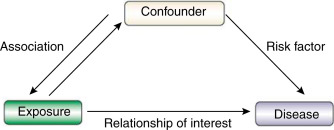

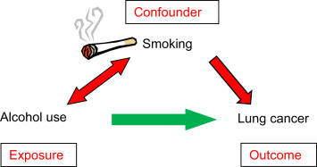

From the `2_QC` script, we determined that the following variables contribute towards the variability in our data:

- Trimester
- flowCell
- RQS
- Processing_time

So, if we want to see the genes differentially expressed by Trimester, then we have to control for the other 3 variables, and so on.

To do our differential expression analysis, we will use a statistical test called as linear regression

To run this test, we first need to make a matrix, called the `model matrix` which includes the main variable by which we want to assess DE by and all the confounders that we are going to use in our model

#### **3.1 Trimester**

```r
tri_mat <- model.matrix(~Trimester + flowCell + RQS + Processing_time, data = pDat)

tri_mat
```

```
##    (Intercept) Trimester2 Trimester3 flowCellC5JC4ACXX flowCellC6RGTANXX  RQS
## 1            1          1          0                 1                 0 3.30
## 2            1          1          0                 1                 0 4.00
## 3            1          1          0                 1                 0 3.60
## 4            1          1          0                 1                 0 3.40
## 5            1          1          0                 1                 0 4.00
## 6            1          1          0                 1                 0 4.00
## 7            1          1          0                 0                 0 2.60
## 8            1          1          0                 0                 0 4.00
## 9            1          1          0                 0                 0 3.50
## 10           1          1          0                 0                 0 3.40
## 11           1          0          0                 0                 1 4.88
## 12           1          0          0                 0                 1 5.11
## 13           1          0          0                 0                 1 6.32
## 14           1          1          0                 0                 1 0.00
```

[output cut: 55 more lines]

What you’ll see now is all the variables that we want, along with the values for each sample, where 0 represents that variable is not present for the sample, and 1 indicating that it is. The intercept column is the baseline variable by which you’re measuring the variable against - here by default it is Trimester 1

We’re now going to fit the matrix to our normalized gene expression (make sure that the genes are rownames) and then apply an additional method called as Empirical Bayes analysis - which updates the distribution of our results from the linear model based on something called as [prior probability](http://varianceexplained.org/r/empirical_bayes_baseball/), which is the original distribution of our data

```r
# fitting the linear model
tri_fit <- lmFit(eNorm, design = tri_mat)

# Empirical Bayes
tri_efit <- eBayes(tri_fit) #ignore the warning
```

And now, we’re going to pull out the top 10 DE miRNAs, using the `topTable` function setting the following parameters:

- `coef = 1` = that we want trimester 1 as the variable
- `adjust.method = "BH"` = that we want to apply the Benjamini-Hochberg/False Discovery Method (FDR) method of multiple tesing correction
- `p.value <= 0.05` = keep only genes with an adjusted p-value of 0.05 or less
- `sort.by = "logFC"` = sort by highest to lowest log-fold-change

**What is a p-value? How do you decide if something is at a significant p-value or not?**

**What is fold change?**

```r
topTable(tri_efit, adjust.method = "BH", coef = 1, p.value = 0.05, sort.by = "logFC")
```

```
##                    logFC  AveExpr         t      P.Value    adj.P.Val         B
## hsa-miR-22-3p   17.50230 16.00000 13.831992 9.606324e-13 1.866247e-10 18.363465
## hsa-miR-516a-5p 16.67615 13.33333 10.417463 2.954432e-10 1.002162e-08 12.441117
## hsa-miR-24-3p   16.10786 14.66667 11.047648 9.357558e-11 3.999420e-09 13.628415
## hsa-miR-517a-3p 15.95276 15.36667  8.085657 3.180460e-08 5.394161e-07  7.621163
## hsa-miR-517b-3p 15.95276 15.36667  8.085657 3.180460e-08 5.394161e-07  7.621163
## hsa-miR-99b-5p  14.78387 15.06667 16.460179 2.375313e-14 1.269011e-11 22.193137
## hsa-miR-27a-3p  14.64855 12.80000 13.287464 2.217892e-12 3.024140e-10 17.497672
## hsa-miR-26b-5p  14.47341 13.00000  9.442890 1.919391e-09 4.825575e-08 10.510755
## hsa-miR-143-3p  14.36760 16.36667 12.856771 4.381751e-12 4.590974e-10 16.793260
## hsa-miR-200c-3p 14.27849 11.83333  8.059749 3.363513e-08 5.615489e-07  7.563671
```

```r
#to get the summary of number of significant and non-significant genes at our multiple testing parameters
decideTests(tri_efit, adjust.method = "BH", p.value = 0.05) %>%
  summary()
```

```
##        (Intercept) Trimester2 Trimester3 flowCellC5JC4ACXX flowCellC6RGTANXX
## Down             1         15         58                 1                 3
## NotSig        1674       2110       2029              2136              2132
## Up             462         12         50                 0                 2
##         RQS Processing_time
## Down      4               0
## NotSig 2132            2135
## Up        1               2
```

```r
# to get all the results, and not just the top 10 - you can also specify the name of the coefficient by looking at the model matrix column names (coef = "Trimester2")
demirs_tri_1 <- topTable(tri_efit, adjust.method = "BH", coef = 1, p.value = 0.05, sort.by = "logFC", n = Inf)
```

What we’ve got now are miRNAs that are DE between Trimester 1 and Trimester 2+3 combined i.e., expressed differently in trimester 1 of the pregnancy in comparison to later on in pregnancy/the rest of the pregnancy (essentially a binary variable question)

```r
tri_sig_1 <- demirs_tri_1 %>%
  filter(adj.P.Val <= 0.05) %>%
  mutate(l2fc_filter = case_when(
                    logFC >= 1 ~ "Significant",
                    logFC <= -1 ~ "Significant",
                    between(logFC, -1, 1) ~ "Not Significant")) %>%
                    filter(l2fc_filter == "Not Significant")
```

We’re now going to make a Volcano Plot which shows us the distribution of our miRNAs by p-value and logFC - we’ll include all the miRNAs, both significant and non

**Make a new column denoting whether a miR is significant or not significant at a p-value <= 0.05 and a logFC of either >=1 or <= -1** - Double check your case_when results, you’re going to have to use multiple arguments to get the exact results from the pval + logFC combinations

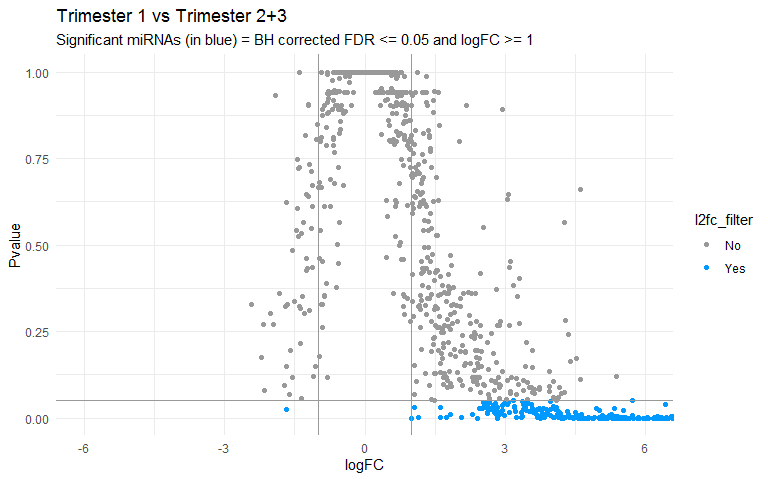

```r
all_tri1 <- topTable(tri_efit, adjust.method = "BH", coef = 1, p.value = 1, sort.by = "logFC", n = Inf)

all_tri1 <- all_tri1 %>%
    mutate(l2fc_filter = case_when(
    logFC >= 1 & adj.P.Val <= 0.05 ~ "Yes",
    logFC >= 1 & adj.P.Val >= 0.05 ~ "No",
    logFC <= -1 & adj.P.Val <= 0.05 ~ "Yes",
    logFC <= -1 & adj.P.Val >= 0.05 ~ "No",
    between(logFC, -1, 1) & adj.P.Val < 0.05 ~ "No",
    between(logFC, -1, 1) & adj.P.Val > 0.05 ~ "No"
  ))

all_tri1 %>%
  ggplot(aes(x = logFC, y = adj.P.Val, colour = l2fc_filter)) +
  geom_point() +
  coord_cartesian(x = c(-6,6)) +
  geom_vline(xintercept = c(-1, 1), color = "#999999") +
  geom_hline(yintercept = 0.05, color = "#999999") +
  scale_colour_manual(values = c("#999999", "#0099ff")) +
  theme_minimal() +
  labs(x = "logFC", y = "Pvalue", title = "Trimester 1 vs Trimester 2+3", subtitle = "Significant miRNAs (in blue) = BH corrected FDR <= 0.05 and logFC >= 1")
```

So, all our significant DEmiRs at adjusted pval <= 0.05 + logFC of >= 1 are coloured in blue - but that doesn’t look like a volcano plot tho - to get better vizualization, this y-axis of type of plot is converted to -log10 scale (the negative value flips the scale, and the log10 enhances it)

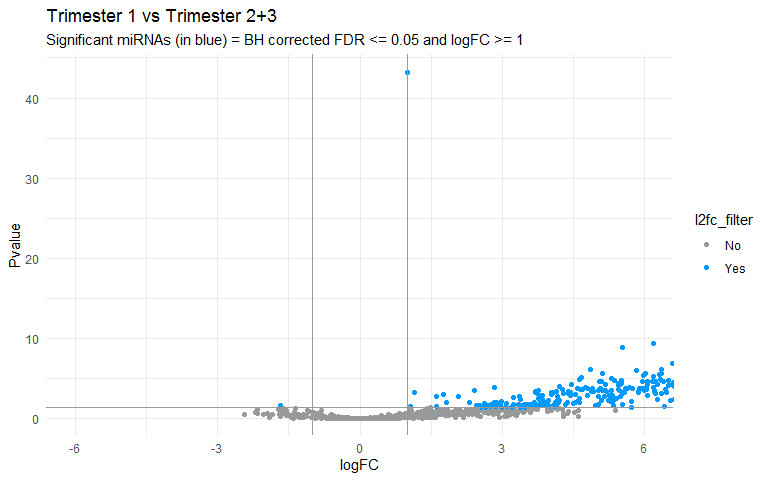

```r
all_tri1 %>%
  ggplot(aes(x = logFC, y = -log10(adj.P.Val), colour = l2fc_filter)) +
  geom_point() +
  coord_cartesian(x = c(-6,6)) +
  geom_vline(xintercept = c(-1, 1), color = "#999999") +
  geom_hline(yintercept = -log10(0.05), color = "#999999") +
  scale_colour_manual(values = c("#999999", "#0099ff")) +
  theme_minimal() +
  labs(x = "logFC", y = "Pvalue", title = "Trimester 1 vs Trimester 2+3", subtitle = "Significant miRNAs (in blue) = BH corrected FDR <= 0.05 and logFC >= 1")
```

**Select the DEmiRNAs for trimester 2 and then trimester 3, and make their respective volcano plots**

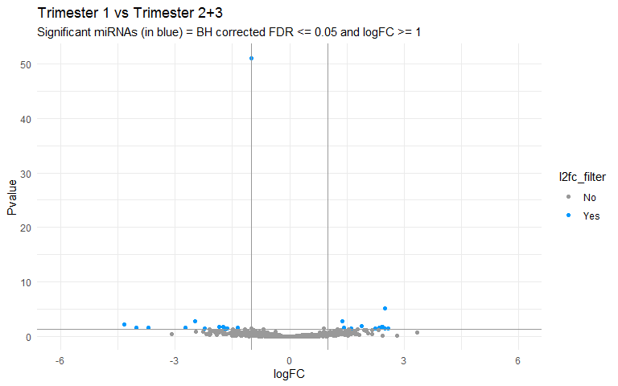

```r
all_tri2 <- topTable(tri_efit, adjust.method = "BH", coef = "Trimester2", p.value = 1, sort.by = "logFC", n = Inf)

all_tri2 <- all_tri2 %>%
    mutate(l2fc_filter = case_when(
    logFC >= 1 & adj.P.Val <= 0.05 ~ "Yes",
    logFC >= 1 & adj.P.Val >= 0.05 ~ "No",
    logFC <= -1 & adj.P.Val <= 0.05 ~ "Yes",
    logFC <= -1 & adj.P.Val >= 0.05 ~ "No",
    between(logFC, -1, 1) & adj.P.Val < 0.05 ~ "No",
    between(logFC, -1, 1) & adj.P.Val > 0.05 ~ "No"
  ))

all_tri2 %>%
  ggplot(aes(x = logFC, y = -log10(adj.P.Val), colour = l2fc_filter)) +
  geom_point() +
  coord_cartesian(x = c(-6,6)) +
  geom_vline(xintercept = c(-1, 1), color = "#999999") +
  geom_hline(yintercept = -log10(0.05), color = "#999999") +
  scale_colour_manual(values = c("#999999", "#0099ff")) +
  theme_minimal() +
  labs(x = "logFC", y = "Pvalue", title = "Trimester 1 vs Trimester 2+3", subtitle = "Significant miRNAs (in blue) = BH corrected FDR <= 0.05 and logFC >= 1")
```

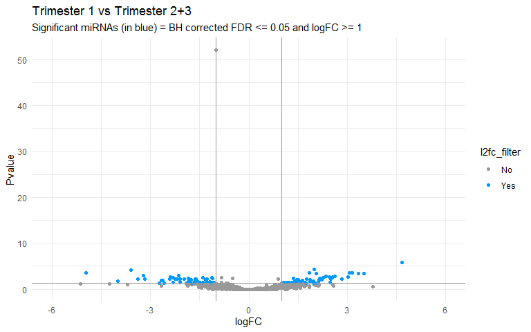

```r
all_tri3 <- topTable(tri_efit, adjust.method = "BH", coef = "Trimester3", p.value = 1, sort.by = "logFC", n = Inf)

all_tri3 <- all_tri3 %>%
    mutate(l2fc_filter = case_when(
    logFC >= 1 & adj.P.Val <= 0.05 ~ "Yes",
    logFC >= 1 & adj.P.Val >= 0.05 ~ "No",
    logFC <= -1 & adj.P.Val <= 0.05 ~ "Yes",
    logFC <= -1 & adj.P.Val >= 0.05 ~ "No",
    between(logFC, -1, 1) & adj.P.Val < 0.05 ~ "No",
    between(logFC, -1, 1) & adj.P.Val > 0.05 ~ "No"
  ))

all_tri3 %>%
  ggplot(aes(x = logFC, y = -log10(adj.P.Val), colour = l2fc_filter)) +
  geom_point() +
  coord_cartesian(x = c(-6,6)) +
  geom_vline(xintercept = c(-1, 1), color = "#999999") +
  geom_hline(yintercept = -log10(0.05), color = "#999999") +
  scale_colour_manual(values = c("#999999", "#0099ff")) +
  theme_minimal() +
  labs(x = "logFC", y = "Pvalue", title = "Trimester 1 vs Trimester 2+3", subtitle = "Significant miRNAs (in blue) = BH corrected FDR <= 0.05 and logFC >= 1")
```

**Now, do the following:**

- **Filter to only keep the significant miRNAs in all three trimester comparisons**

```r
tri_sig_1 <- all_tri1 %>%
  filter(l2fc_filter == "Yes")

tri_sig_2 <- all_tri2 %>%
  filter(l2fc_filter == "Yes")

tri_sig_3 <- all_tri3 %>%
  filter(l2fc_filter == "Yes")
```

- **Add a column to each of the dfs denoting the coefficient/trimester for which we selected to get the results**

```r
tri_sig_1$coef <- "Trimester_1"
tri_sig_2$coef <- "Trimester_2"
tri_sig_3$coef <- "Trimester_3"
```

- **Check if there are any common significant miRNAs between the three comparisons**

```r
tri_sig_1 <- tri_sig_1 %>%
  rownames_to_column("miRNA")
tri_sig_2 <- tri_sig_2 %>%
  rownames_to_column("miRNA")
tri_sig_3 <- tri_sig_3 %>%
  rownames_to_column("miRNA")

common_tri <- tri_sig_1 %>%
  inner_join(tri_sig_2, by = "miRNA") %>%
  inner_join(tri_sig_3, by = "miRNA")
```

**CHECKPOINT:** You should have:

- 463 miRNAs in tri_sig_1
- 24 miRNAs in tri_sig_2
- 101 miRNAs in tri_sig_3
- 10 common DEmiRNAs
- **Make a boxplot showing the normalized expression of the common DEmiRNAs by Trimester**

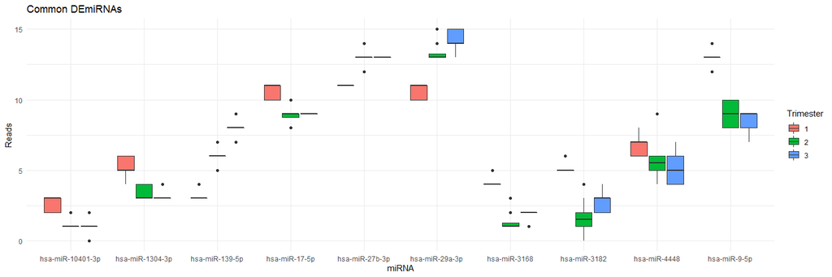

```r
common_tri %>%
  left_join(eNorm_plot, by = c("miRNA" = "mirs")) %>%
  ggplot(aes(x = miRNA, y = Reads, fill = Trimester)) +
  geom_boxplot() +
  theme_minimal() +
  labs(title = "Common DEmiRNAs", x = "miRNA", y = "Reads")
```

#### **3.1.2 With Contrasts**

Now, this plot doesn’t seem to make much sense, but given that we compared one trimester to the rest of the two *together*, we didn’t select the miRNAs that showed a difference in expression in each trimester - e.g., Trimester 1 compared to Trimester 2+3 is different than Trimester 1 compared to Trimester 2 and Trimester 1 compared to Trimester 3

That’s what we’ll do now then - compare the differences separately by using a separate matrix within our linear model called a contrast matrix. This type of matrix is very useful when you want to compare timepoints or conditions by each of the values within that variable

```r
conMat <- makeContrasts(
  t2_vs_t1 = Trimester2 - Intercept,
  t3_vs_t1 = Trimester3 - Intercept,
  t3_vs_t2 = Trimester3 - Trimester2,
  levels = tri_mat
)
con_fit <- contrasts.fit(tri_fit, conMat) %>%
  eBayes()
topTable(con_fit, adjust.method = "BH", coef = 1, p.value = 0.05, sort.by = "logFC")
```

```
##                     logFC   AveExpr          t      P.Value    adj.P.Val
## hsa-miR-516a-5p -18.36041 13.333333  -8.455572 1.444531e-08 6.157163e-07
## hsa-miR-22-3p   -18.11106 16.000000 -10.551833 2.303209e-10 5.267497e-08
## hsa-miR-9-5p    -17.77951  9.466667  -7.296792 1.819234e-07 5.183604e-06
## hsa-miR-451a    -15.21508 11.000000  -5.122754 3.289114e-05 3.904910e-04
## hsa-miR-200c-3p -15.00102 11.833333  -6.242442 2.121482e-06 3.778006e-05
## hsa-miR-518e-5p -14.82583 14.300000  -9.668130 1.232574e-09 1.013081e-07
## hsa-miR-519b-5p -14.82583 14.300000  -9.668130 1.232574e-09 1.013081e-07
## hsa-miR-519c-5p -14.82583 14.300000  -9.668130 1.232574e-09 1.013081e-07
## hsa-miR-522-5p  -14.82583 14.300000  -9.668130 1.232574e-09 1.013081e-07
## hsa-miR-523-5p  -14.82583 14.300000  -9.668130 1.232574e-09 1.013081e-07
##                          B
## hsa-miR-516a-5p  8.5488496
## hsa-miR-22-3p   12.8127931
## hsa-miR-9-5p     5.9489800
## hsa-miR-451a     0.6604583
## hsa-miR-200c-3p  3.4397170
## hsa-miR-518e-5p 11.0827684
## hsa-miR-519b-5p 11.0827684
## hsa-miR-519c-5p 11.0827684
## hsa-miR-522-5p  11.0827684
## hsa-miR-523-5p  11.0827684
```

```r
decideTests(con_fit, adjust.method = "BH", p.value = 0.05) %>%
  summary()
```

```
##        t2_vs_t1 t3_vs_t1 t3_vs_t2
## Down        383      395       30
## NotSig     1751     1739     2093
## Up            3        3       14
```

**Make dfs of the significant DEmiRNAs as above, check if there are any common DEmiRNAs and plot a boxplot and dotplot by trimester for the common**

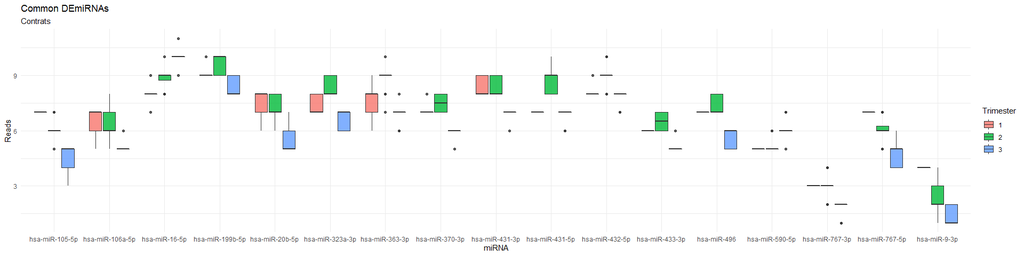

```r
t2_t1 <- topTable(con_fit, n = Inf, adjust.method = "fdr", coef = 1, p.value = 0.05, sort.by = "logFC")
t3_t1 <- topTable(con_fit, n = Inf, adjust.method = "fdr", coef = 2, p.value = 0.05, sort.by = "logFC")
t3_t2 <- topTable(con_fit, n = Inf, adjust.method = "fdr", coef = 3, p.value = 0.05, sort.by = "logFC")

sig_t2_t1 <- t2_t1 %>%
  filter(logFC >= 1 | logFC <= -1) %>%
  rownames_to_column("miRNA")

sig_t3_t1 <- t3_t1 %>%
  filter(logFC >= 1 | logFC <= -1) %>%
  rownames_to_column("miRNA")

sig_t3_t2 <- t3_t2 %>%
  filter(logFC >= 1 | logFC <= -1) %>%
  rownames_to_column("miRNA")

common_con_tri <- sig_t2_t1 %>%
  inner_join(sig_t3_t1, by = "miRNA") %>%
  inner_join(sig_t3_t2, by = "miRNA")

common_con_tri %>%
  left_join(eNorm_plot, by = c("miRNA" = "mirs")) %>%
  ggplot(aes(x = miRNA, y = Reads, fill = Trimester)) +
  geom_boxplot(alpha = 0.8) +
  theme_minimal() +
  labs(title = "Common DEmiRNAs", subtitle = "Contrats",  x = "miRNA", y = "Reads")
```

**CHECKPOINT:** You should have 17 common DEmiRNA

### 4.0 **Formatting the [Smith et al.,](https://www.tandfonline.com/doi/full/10.1080/15476286.2021.1963105) data**

I’ve downloaded the relevant files from Melanie Smith’s GitHub into the `data/external/` folder, where:

- counts_placenta.txt = raw miRNA counts
- sampleMeta.txt = Meta data
- earlyPlacentamiRNA_SeqProfile = Melanie’s workflow

If you go through her workflow script, you’ll see that she has some initial formatting of the sample names for the `counts_placenta` raw expression data.

**Using relevant object names, read in the Melanie’s data and apply the initial formatting steps that she did.** Can you improve her code? Does it need to be improved, or is it simple and clear enough?

```r
smith_eDat_raw <- read.delim("G:/My Drive/UBC Docs/Mentorship/Fidan/SSRP_FidanSadig/data/external/counts_placenta.txt")
smith_mDat <- read.delim("G:/My Drive/UBC Docs/Mentorship/Fidan/SSRP_FidanSadig/data/external/sampleMeta.txt")
```

```r
# drop sample Q131 and Q071 - low reads identified in FastQC
# countsPlacenta <- dplyr::select(countsPlacenta, -which(names(countsPlacenta) %in% c("Q131_merge_R1", "Q071_merge_R1")))

# ---> my code edit
countsPlacenta <- smith_eDat_raw %>%
  column_to_rownames("mirna") %>%
  dplyr::select(-Q131_merge_R1, -Q071_merge_R1)


# remove the "_merge_R1" from the sample name for simplification
# names(countsPlacenta) <- sub("_merge_R1","",names(countsPlacenta))
# ---> my code edit
colnames_placenta <- as.data.frame(names(countsPlacenta))
colnames_placenta$drop_R1 <- str_replace(colnames_placenta$`names(countsPlacenta)`, pattern = "_merge_R1", replacement = "")
# OR
# colnames_placenta$drop_R1 <- str_sub(colnames_placenta$`names(countsPlacenta)`, end = -10)


# remove the "Q" prefix from the sample names and replace with PAC
# names(countsPlacenta) <- sub("Q","",names(countsPlacenta))
# ---> my code edit
colnames_placenta$drop_Q <- str_replace(colnames_placenta$drop_R1, pattern = "Q", replacement = "")


# Create a df of sample names from the counts table, then add PAC prefix and pad to 7 characters
# countsPlacentaNames <- data.frame(names(countsPlacenta)) %>%
#  mutate(names.countsPlacenta. = paste0("PAC",stringr::str_pad(names.countsPlacenta., width = 4, pad = "0")))
# ---> my code edit
colnames_placenta <- colnames_placenta %>%
  mutate(new_name = paste0("PAC", str_pad(drop_Q, width = 4, pad = "0")))


# convert back to a vector and overwrite the colnames in the counts table
# countsPlacentaNames <- countsPlacentaNames[,]
# replace the old sample names with the new names (PACXXXX)
# names(countsPlacenta) <- countsPlacentaNames
# ---> my code edit
all(names(countsPlacenta) == colnames_placenta$`names(countsPlacenta)`)
```

```
## [1] TRUE
```

```r
colnames(countsPlacenta) <- colnames_placenta$new_name

# ensure the columns are ordered by assending sample name
countsPlacenta <- countsPlacenta[,order(colnames(countsPlacenta), decreasing = FALSE)]

smith_eDat <- countsPlacenta
```

**What does `processGroup` signify in this script?**

- `processGroup` = representing the sequencing batch and used for correcting for technical variance

**Recode Melanie’s mDat variable names to match our variable names as much as possible - keep all orginal columns**

Trimester 1 < 13 weeks  
Trimester 2 13 < x < 24 weeks  
Trimester 3 >= 24 weeks

```r
smith_mDat <- smith_mDat %>%
  mutate(Trimester = case_when(
    gestationalAge < 13 ~ "1",
    between(gestationalAge, 13, 24) ~ "2",
    gestationalAge >- 24 ~ "3"),
    Sex = case_when(
      fetalSex == "XY" ~ "MALE",
      fetalSex == "XX" ~ "FEMALE")
  )

smith_mDat <- smith_mDat %>%
  filter(samplename != "PAC0131") %>%
  filter(samplename != "PAC0071")
```

**Show the distribution of samples by:**

- trimester + sex
- trimester + sex + oxygenation

*Hint*: Add geom_bar(stat = “count”, position = position_dodge2(preserve = “single”))

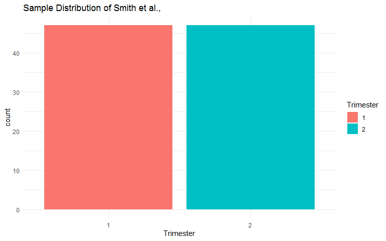

```r
smith_mDat %>%
  ggplot(aes(x = Trimester, fill = Trimester)) +
  geom_bar(stat = "count") +
  theme_minimal() +
  labs(title = "Sample Distribution of Smith et al.,")
```

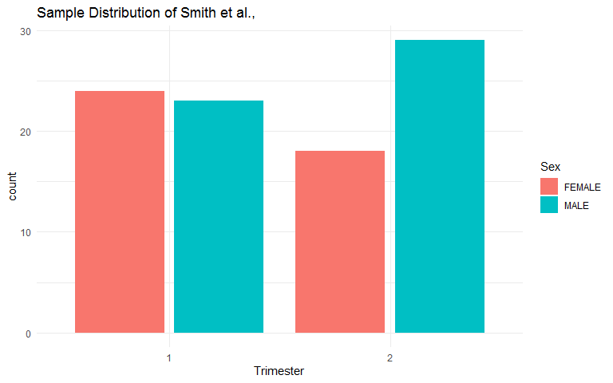

```r
smith_mDat %>%
  ggplot(aes(x = Trimester, fill = Sex)) +
  geom_bar(stat = "count", position = position_dodge2(preserve = "single")) +
  theme_minimal() +
  labs(title = "Sample Distribution of Smith et al.,")
```

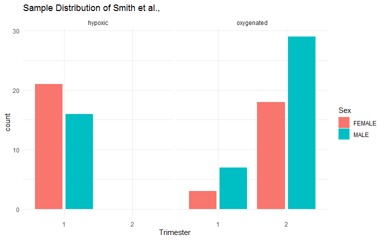

```r
smith_mDat %>%
  ggplot(aes(x = Trimester, fill = Sex)) +
  geom_bar(stat = "count", position = position_dodge2(preserve = "single")) +
  theme_minimal() +
  labs(title = "Sample Distribution of Smith et al.,") +
  facet_grid(cols = vars(oxygenation))
```

**Filter and Normalize this data as we did for our data**

```r
smith_0 <- smith_eDat %>%
  filter_all(any_vars(. > 0))

smith_0 %>%
  mutate(Sums = rowSums(.)) %>%
  filter (Sums == 0)
```

```
##  [1] PAC0006 PAC0007 PAC0008 PAC0009 PAC0010 PAC0011 PAC0012 PAC0013 PAC0014
## [10] PAC0015 PAC0016 PAC0017 PAC0018 PAC0020 PAC0021 PAC0022 PAC0023 PAC0024
## [19] PAC0025 PAC0026 PAC0027 PAC0029 PAC0030 PAC0031 PAC0032 PAC0033 PAC0034
## [28] PAC0035 PAC0036 PAC0037 PAC0038 PAC0039 PAC0040 PAC0041 PAC0042 PAC0043
## [37] PAC0044 PAC0045 PAC0046 PAC0047 PAC0048 PAC0049 PAC0050 PAC0051 PAC0052
## [46] PAC0053 PAC0054 PAC0055 PAC0056 PAC0057 PAC0058 PAC0059 PAC0060 PAC0062
## [55] PAC0063 PAC0064 PAC0065 PAC0069 PAC0070 PAC0072 PAC0074 PAC0075 PAC0076
## [64] PAC0077 PAC0078 PAC0083 PAC0084 PAC0086 PAC0087 PAC0088 PAC0091 PAC0093
## [73] PAC0097 PAC0098 PAC0099 PAC0100 PAC0102 PAC0103 PAC0105 PAC0107 PAC0108
## [82] PAC0109 PAC0111 PAC0114 PAC0117 PAC0118 PAC0120 PAC0122 PAC0124 PAC0127
## [91] PAC0129 PAC0134 PAC0139 PAC0140 Sums
## <0 rows> (or 0-length row.names)
```

```r
smith_1_2 <- smith_0 >=1

smith_1_2 <- smith_1_2 %>%
  as.data.frame() %>%
  mutate(Sum = rowSums(.))

smith_1_2 <- smith_1_2 %>%
  filter(Sum >= 2)

smith_0 <- smith_0 %>%
  rownames_to_column("miRNA")

smith_eFil <- smith_1_2 %>%
  rownames_to_column("miRNA") %>%
  dplyr::select(miRNA) %>%
  left_join(smith_0, by = "miRNA")
```

```r
smith_eFil <- smith_eFil %>%
  mutate(Sum = rowSums(select_if(., is.numeric))) %>%
  group_by(miRNA) %>%
  slice_max(Sum) %>%
  dplyr::select(-Sum) %>%
  distinct(miRNA, .keep_all = TRUE) %>%
  column_to_rownames("miRNA")
```

```r
smith_mir_names <- as.data.frame(row.names(smith_eFil))
samples <- smith_mDat$samplename
norm_counts <- DGEList(counts = smith_eFil, samples = samples, genes = smith_mir_names)
norm_counts <- calcNormFactors(norm_counts, method = "RLE")
smith_eNorm <- cpm(norm_counts)

smith_eNorm <- log2(smith_eNorm + 1)
smith_eNorm <- round(smith_eNorm, digits = 0)

smith_eNorm <- as.data.frame(smith_eNorm)
```

**Plot the density and boxplot distribution of `smith_eNorm`**

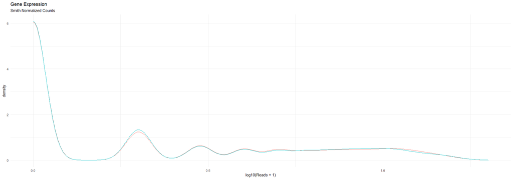

```r
smith_plot <- smith_eNorm %>%
  rownames_to_column("miRNA") %>%
  pivot_longer(cols = c(-miRNA), names_to = "samplename", values_to = "Reads") %>%
  left_join(smith_mDat, by = "samplename")


smith_plot %>%
  ggplot(aes(x = log10(Reads + 1), colour = Trimester)) +
  geom_density() +
  theme_minimal() +
  theme(legend.position = "none") +
  labs(title = "Gene Expression", subtitle = "Smith Normalized Counts")
```

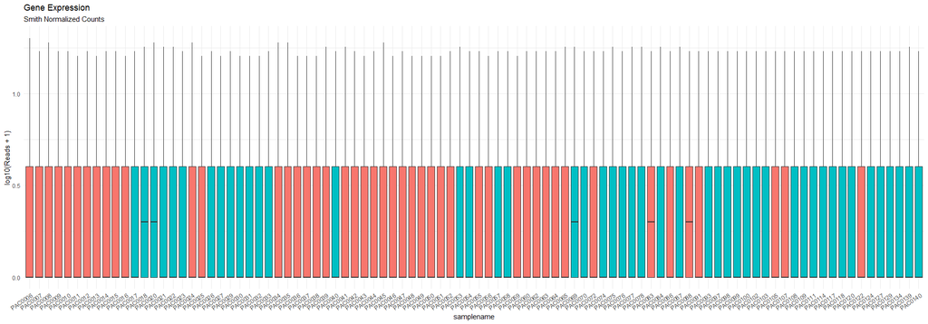

```r
smith_plot %>%
  ggplot(aes(x = samplename, y = log10(Reads + 1), fill = Trimester)) +
  geom_boxplot() +
  theme_minimal() +
  theme(legend.position = "none") +
  theme(axis.text.x = element_text(angle = 35, hjust = 1)) + #to rotate the x axis lables by 35 degrees and lower them by 1 degree
  labs(title = "Gene Expression", subtitle = "Smith Normalized Counts")
```

**Save smith_mDat and smith_eNorm as R objects**

```r
saveRDS(smith_eNorm_log2, "G:/My Drive/UBC Docs/Mentorship/Fidan/Worksheets_filled/smith_eNorm_log2.rds")
saveRDS(smith_mDat, "G:/My Drive/UBC Docs/Mentorship/Fidan/Worksheets_filled/smith_mDat.RDS")
write.xlsx(common_con_tri, "G:/My Drive/UBC Docs/Mentorship/Fidan/Worksheets_filled/common_DEmiRNAs.xlsx")


wb <- createWorkbook()
addWorksheet(wb, "sig_t2_t1")
addWorksheet(wb, "sig_t3_t1")
addWorksheet(wb, "sig_t3_t2")

writeData(wb, "sig_t2_t1", sig_t2_t1)
writeData(wb, "sig_t3_t1", sig_t3_t1)
writeData(wb, "sig_t3_t2", sig_t3_t2)

saveWorkbook(wb, "G:/My Drive/UBC Docs/Mentorship/Fidan/Worksheets_filled/DEmiRNAs_contrast.xlsx", overwrite = TRUE)
```